# Introdução ao MediadoR

Gabriel Pistelli Ferreira

2022-07-08

## Introdução

O MediadoR pretende se tornar um instrumento que auxilie os pesquisadores de negociações coletivas por todo o Brasil, oferecendo um método simples e fácil de realizar estas pesquisas. Para fazer isto, pretendemos trazer contribuições em basicamente três frentes:

- Oferecer um webscraper das negociações coletivas disponibilizadas na plataforma MediadoR, organizando-os em um vetor de caracteres que pode facilmente ser juntado em um data.frame
- Adiantar alguns processos de limpeza dos dados, introduzindo funções que retiram dados percentuais e monetários
- E, por fim, unificar pesquisadores em torno de uma plataforma que agregue diversos dados e que possa ser facilmente acessível por todos

Buscamos reforçar este foco em compartilhar nosso instrumento também através da abertura de nosso código em um [repositório](https://github.com/gpistelli/MediadoR) no github. Também convidamos todas e todos pesquisadores a contribuírem nele. Se você quiser ajudar, comece lendo nosso Readme para se ter uma ideia melhor de nossa proposta e objetivos.

Este documento, então, é uma breve introdução ao estado atual de nossas funções e elementos que podemos extrair delas.

## Instalação do pacote e citação

Organizamos nosso pacote a partir dos pacotes `tidyverse`, em especial `stringr` e `dplyr`, para a manipulação dos dados, e o `rvest` para realizar o webscraping das páginas das negociações coletivas, o que demanda que estes sejam instalados no seu computador. Se eles não estiverem instalados, nosso código simplesmente não irá funcionar, mas não se preocupe, este processo já é automatizado pelo `devtools` na instalação de nosso pacote:

```r
# Se você não tem o devtools instalado, instale-o:
install.packages("devtools")

# A partir daí é só colocar o próximo código:
devtools::install_github(repo = "gpistelli/MediadoR", subdir = "pkg")
```

Para construir esta introdução, usaremos, além dos pacotes chamados pelo MediadoR, o `tidyverse` e o `rmarkdown`.

```r
library(tidyverse)
library(rmarkdown)
library(MediadoR)
```

Se você utilizar nossoo pacote em seu trabalho, não se esqueça de citá-lo. Seu formato na ABNT seria mais ou menos o seguinte:

```
FERREIRA, Gabriel Pistelli. MediadoR: A Tool to Research Brazilian Collective Bargaining. R Package version 0.1. 2022. Disponível em: <https://github.com/gpistelli/MediadoR>.
```

## Coletando dados de um link

Para coletar dados de uma negociação coletiva, utilizamos a função `CCT.get_complete_CCT`, que é basicamente um wrapper das funções que, respectivamente, baixam a página da negocição, lêem os dados na plataforma e que organizam esses dados. Em alguns casos de conexões lenta e de instabilidade da plataforma uma estratégia de solução dos problemas pode ser baixar os dados anteriormente. Neste caso, sugere-se que se baixe o documento com o `download.file()` e utilize o arquivo como parte do parâmetro `path`.

Se tivermos demanda e apoio, podemos pensar em criar uma versão de leitura local ou, ainda, de acordos em formato pdf. Mas, no presente momento, isto não é uma prioridade, uma vez que nossas funções já dão conta do recado, em nossa opinião, tendo o método do download anterior como uma boa alternativa a uma eventual demora no processamento dos dados.

Quando chamamos esta função, então, possuímos o seguinte retorno:

```r
# Criar a função da leitura de um documento já baixado (FUNCTION)
NCT_get_complete_NCT("http://www3.mte.gov.br/sistemas/mediador/Resumo/ResumoVisualizar?NrSolicitacao=MR039775/2018") %>% t() %>% as.data.frame()
```

| VIGÊNCIA E DATA-BASE | ABRANGÊNCIA | PISO SALARIAL | CORREÇÃO SALARIAL | MORA SALARIAL | CONTRATO FORA DE DOMICÍLIO | INDENIZAÇÃO POR TEMPO DE SERVIÇO | AUXILIO MORADIA | AUXILIO ALIMENTAÇÃO | AUXILIO FUNERAL | SEGURO DE VIDA/INDENIZAÇÃO | EMPREGADO EM VIAS DE APOSENTADORIA | ABONO APOSENTADORIA | QUALIFICAÇÃO PROFISSIONAL | PARTICIPAÇÃO EM CURSO | RESPONSABILIDADE TÉCNICA | MATERIAL DE TRABALHO | TRABALHO EM JORNADA EXCEPCIONAL | COMPENSAÇÃO DE TRABALHO NO NATAL, ANO NOVO E DIAS PONTE | JORNADA DE TRABALHO | FERIAS | GARANTIA DE EMPREGO APOS O RETORNO DE FÉRIAS | DISPENSA DE DIRETORES SINDICAIS | DESCONTOS DE MENSALIDADE EM FOLHA DE PAGAMENTO | CONTRIBUIÇÃO SINDICAL | CUSTEIO NEGOCIAL | QUADRO DE AVISOS | RELAÇÃO DE EMPREGADOS | ATA DE REUNIÃO | NEGOCIAÇÕES PERMAMENTES | … |
| --- | --- | --- | --- | --- | --- | --- | --- | --- | --- | --- | --- | --- | --- | --- | --- | --- | --- | --- | --- | --- | --- | --- | --- | --- | --- | --- | --- | --- | --- | --- |
| CLÁUSULA PRIMEIRA - VIGÊNCIA E DATA-BASE | CLÁUSULA SEGUNDA - ABRANGÊNCIA dos profissionais Liberais, dos ENGENHEIROS, representados pelo SENGE/PR Abatiá/PR, Adrianópolis/PR, Agudos Do Sul/PR, Almirante Tamandaré/PR, Altamira Do Paraná/PR, Alt… | CLÁUSULA TERCEIRA - PISO SALARIAL Fica estabelecido que nenhum profissional representado pelo SENGE-PR poderá receber salário inferior ao fixado na lei 4950-A/66 de 22 de abril de 1966 Reajustes/Corre… | CLÁUSULA QUARTA - CORREÇÃO SALARIAL A partir de 1º de junho de 2017, os salários serão reajustados pelo índice de 3% (três por cento) a ser aplicado sobre os salários vigentes em 1º de junho de 2017, … | CLÁUSULA QUINTA - MORA SALARIAL Ocorrendo atraso no pagamento de quaisquer verbas de natureza salarial, incidirá a multa de 4% (quatro por cento) sobre o salário base, por mês ou pro rata de atraso at… | CLÁUSULA SEXTA - CONTRATO FORA DE DOMICÍLIO O empregado contratado fora de domicílio que tenha tido sua passagem de ida paga pelo empregador, terá garantida sua passagem de retorno ao mesmo local da c… | CLÁUSULA SÉTIMA - INDENIZAÇÃO POR TEMPO DE SERVIÇO Na rescisão contratual sem justa causa, os empregados farão jus a uma indenização em virtude do tempo de serviço ininterrupto na empresa, fixada de a… | CLÁUSULA OITAVA - AUXILIO MORADIA O empregado no curso de aviso prévio, trabalhado ou indenizado, permanecerá na moradia fornecida pela empresa até o quinto dia após o término deste e pagamento das ve… | CLÁUSULA NONA - AUXILIO ALIMENTAÇÃO As empresas fornecerão gratuitamente uma Cesta Básica com produtos variados, a ser entregue aos empregados no dia 20 de cada mês, a qual poderá ter a seguinte compo… | CLÁUSULA DÉCIMA - AUXILIO FUNERAL Ocorrendo falecimento do empregado, quando a serviço da empresa, competirá à mesma pagar as despesas com o transporte do falecido para seu sepultamento. Seguro de Vid… | CLÁUSULA DÉCIMA PRIMEIRA - SEGURO DE VIDA/INDENIZAÇÃO As empresas garantirão aos seus empregados, por si ou por empresa seguradora, um Seguro de Vida e Acidentes Pessoais em grupo, independente da for… | CLÁUSULA DÉCIMA SEGUNDA - EMPREGADO EM VIAS DE APOSENTADORIA Os empregados em vias de obtenção do direito à aposentadoria farão jus a um período de estabilidade conforme abaixo: a) - Garantia de empre… | CLÁUSULA DÉCIMA TERCEIRA - ABONO APOSENTADORIA O empregados que contarem com mais de 5 (cinco) anos ininterruptos na mesma empresa, quando dela vierem a se desligar por motivo de aposentadoria, farão … | CLÁUSULA DÉCIMA QUARTA - QUALIFICAÇÃO PROFISSIONAL Somente os engenheiros e demais profissionais representados pelo SENGE/PR, legalmente qualificados e devidamente registrados em qualquer CREA, poderã… | CLÁUSULA DÉCIMA QUINTA - PARTICIPAÇÃO EM CURSO Nos casos de cursos promovidos pelo SENGE/PR, os empregados que solicitem, poderão ser liberados, dentro do limite de carga horária de uma semana por sem… | CLÁUSULA DÉCIMA SEXTA - RESPONSABILIDADE TÉCNICA Todos os serviços, inclusive o exercício de cargos e funções, projetos e obras de engenharia serão executados mediante prévia anotação de responsabilid… | CLÁUSULA DÉCIMA SÉTIMA - MATERIAL DE TRABALHO Será fornecido todo material necessário ao desempenho das atividades profissionais, inclusive máquina de calcular, material de desenho técnico, literatura… | CLÁUSULA DÉCIMA OITAVA - TRABALHO EM JORNADA EXCEPCIONAL TRABALHO EM JORNADA EXCEPCIONAL Nos casos em que as obras atinjam estágio inadiável, por exigência técnica, por dispositivos contratuais e, con… | CLÁUSULA DÉCIMA NONA - COMPENSAÇÃO DE TRABALHO NO NATAL, ANO NOVO E DIAS PONTE COMPENSAÇÃO DA DISPENSA DO TRABALHO NO PERÍODO DE NATAL, ANO NOVO E DIAS PO As empresas, em comum acordo com seus emprega… | CLÁUSULA VIGÉSIMA - JORNADA DE TRABALHO A jornada de trabalho normal é de 44 horas semanais e de 220 horas mensais, sendo que o DSR poderá ser programado para qualquer dia da semana, garantindo-se, po… | CLÁUSULA VIGÉSIMA PRIMEIRA - FERIAS O início das férias, coletivas ou individuais, integrais ou parceladas, não poderá coincidir com os sábados, domingos ou dias destinados ao descanso: a) Quando as f… | CLÁUSULA VIGÉSIMA SEGUNDA - GARANTIA DE EMPREGO APOS O RETORNO DE FÉRIAS Fica garantido o emprego pelo período de trinta dias ao empregado que retorne de férias. Relações Sindicais Liberação de Empreg… | CLÁUSULA VIGÉSIMA TERCEIRA - DISPENSA DE DIRETORES SINDICAIS Fica assegurado aos diretores sindicais, não licenciados, a dispensa remunerada, em 2 (dois) dias mensais, para que possam participar das r… | CLÁUSULA VIGÉSIMA QUARTA - DESCONTOS DE MENSALIDADE EM FOLHA DE PAGAMENTO As mensalidades serão descontadas em folha de pagamento, com expressa autorização dos engenheiros associados ao SENGE/PR,nos p… | CLÁUSULA VIGÉSIMA QUINTA - CONTRIBUIÇÃO SINDICAL Nos termos do artigo 578 da CLT, os EMPREGADORES ficam obrigados a descontar na folha de pagamento dos seus empregados a valor da contribuição sindical… | CLÁUSULA VIGÉSIMA SEXTA - CUSTEIO NEGOCIAL Será descontado 2% (um por cento) do salário base de cada engenheiro, geólogo e demais profissionais representados pelo SENGE/PR, título de taxa de Custeio N… | CLÁUSULA VIGÉSIMA SÉTIMA - QUADRO DE AVISOS O empregador manterá o quadro de avisos em locais acessíveis aos empregados, para a fixação de materiais do SENGE-PR e de interesse da categoria sendo vedad… | CLÁUSULA VIGÉSIMA OITAVA - RELAÇÃO DE EMPREGADOS Ocorrendo admissão ou demissão de engenheiros, a empresa remeterá ao SENGE-PR a relação dos membros dos mesmos até o 5º dia útil do mês subsequente àqu… | CLÁUSULA VIGÉSIMA NONA - ATA DE REUNIÃO Em toda e qualquer reunião feita entre o SENGE-PR e o SICEPOT, deverá ser extraída ata correspondente, se uma das partes assim o quiser, a qual será assinada pe… | CLÁUSULA TRIGÉSIMA - NEGOCIAÇÕES PERMAMENTES Fica instituído um canal permanente de negociações e entendimentos entre os Sindicatos convenientes, objetivando atender as necessidades e anseios das part… | … |

Como podemos ver, o código consegue ler qual é a cláusula e organiza estas em diferentes elementos num vetor de caracteres e os nomeia a partir desta cláusula. Isto possibilita que estas cláusulas se posicionem em conjunto e possam ser comparadas ano-a-ano, facilitando a vida do pesquisador que quiser, por exemplo, realizar uma análise diacrônica, focando nas mudanças nas negociações coletivas. Podemos dar um exemplo com dados que já coletamos anteriormente, da convenção coletiva entre o sindicato dos trabalhadores da indústria alimentícia de Curitiba e o Sindicato da Indústria de Trigo, utilizando as funções `lapply`, `do.call` e `bind_rows` (esta última do excelente [tidyverse](https://www.tidyverse.org/), já citado aqui). Para demonstração, apresentamos apenas a terceira coluna, do piso salarial:

```r
CCT_df <- lapply(X = paste0("https://raw.githubusercontent.com/gpistelli/MediadoR/main/data/CCT/Curitiba/Ind%C3%BAstria%20Aliment%C3%ADcia/STIAC/STIAC_SINDITRIGO_", c(2015, 2017, 2019, 2020, 2021), ".csv"), FUN = read.csv, fileEncoding = "utf8") %>%
  do.call(what = bind_rows, args = .) %>% as.data.frame()

knitr::kable(CCT_df[,4])
```

| x |
| --- |
| CLÁUSULA TERCEIRA - SALÁRIO NORMATIVO Fica assegurado aos trabalhadores abrangidos pela presente Convenção, a partir de 01 de Novembro de 2015, os salários de normativos a seguir especificados: Sálári… |
| CLÁUSULA TERCEIRA - SALÁRIO NORMATIVO Fica assegurado aos trabalhadores abrangidos pela presente Convenção, a partir de 01 de Novembro de 2016, os salários normativos a seguir especificados: Salário n… |
| CLÁUSULA TERCEIRA - SALÁRIO NORMATIVO Fica assegurado aos trabalhadores abrangidos pela presente Convenção, a partir de 01 de Novembro de 2018, os salários normativos a seguir especificados: Salário n… |
| CLÁUSULA TERCEIRA - SALÁRIO NORMATIVO Fica assegurado aos trabalhadores abrangidos pela presente Convenção, a partir de 01 de Novembro de 2019, os salários normativos a seguir especificados: Salário n… |
| CLÁUSULA TERCEIRA - SALÁRIO NORMATIVO Fica assegurado aos trabalhadores abrangidos pela presente Convenção, a partir de 01 de Novembro de 2020, os salários normativos a seguir especificados: Salário n… |

Nossos dados, então, se encontram ordenados, o que já é uma contribuição interessante, mas ainda assim teremos problemas que não temos como contornar imediatamente no pacote. Um exemplo disso podem ser os nomes de cláusulas, assim como a formatação destas, os quais podem sofrer alterações estéticas e outros erros humanos que dificultam o processamento adequado dos dados. Ficar atento a estas possibilidades é importante para evitar confusões e demandam o tratamento específico caso a caso das negociações analisadas.

A única alternativa para diminuírmos esses erros é a organização dos pesquisadores no processamento coletivo destes dados, a qual sugerimos que seja feita em nosso repositório. Um bom método de nos ajudar é construir um data.frame a partir de links do MediadoR, ajustá-lo, e assim que os organizar com as linhas tendo como nomes os anos de suas respectivas NC, separar cada linha como um data.frame, para facilitar o acesso direto aos dados ajustados. Sugerimos, para esta empreitada, o seguinte código:

```r
for (i in 1:nrow(CCT_df)){
  write.csv(x = CCT_df[i,],
            file = generate_file_name(sind, negot, df, i),
            fileEncoding = "utf8")
}
```

No caso, troque o `sind` por um caracter do nome do sindicato, o `negot` pela outra parte e o `df` pelo seu data.frame em questão. Assim que tiver estes dados, pode pedir para colocarmos em nosso github, seguindo os padrões pedidos em nosso readme.

## Funções auxiliares

Além da coleta de dados, como falamos, também organizamos algumas funções para nos ajudar na manipulação dos dados. Temos três principais funções desenvolvidas até o presente momento: uma de comparação de cláusulas presentes durante o tempo e outras duas que extraem os dados de valores em reais e percentuais.

Se quisermos saber se há alguma cláusula nova ou retirada, podemos utilizar a função `CCT.find_nold_clauses()`:

```r
knitr::kable(NCT_find_nold_clauses(CCT_df))
```

|  | BASE.TERRITORIAL | CATEGORIAS.ABRANGIDAS | CATEGORIA.ABRANGIDA |
| --- | --- | --- | --- |
| 5 | Retirado | Retirado | Novo |

Estes dados, então, nos ajudam a entender melhor as transformações no período abrangido pelas negociações. Neste caso, não temos nada especial, apenas mudanças estéticas, como advertimos anteriormente.

Outra função importante é a da retirada de valores em Real, as quais podemos utilizar para investigar o piso salarial, o qual, em nosso caso, temos dois pisos na cláusula: daqueles trabalhadores em experiência, nos primeiros 90 dias de trabalho, e os efetivados. Isto demanda que tiremos a média destes valores:

```r
piso_salarial <- NCT_get_monetary_values(CCT_df$SALÁRIO.NORMATIVO) %>% lapply(X = ., FUN = NCT_convert_mon_to_num) %>% lapply(X = ., FUN = mean) %>% unlist()

names(piso_salarial) <- CCT_df$X

knitr::kable(x = piso_salarial)
```

|  | x |
| --- | --- |
| 2015 | 1182.500 |
| 2017 | 1283.025 |
| 2019 | 1405.800 |
| 2020 | 1443.200 |
| 2021 | 1512.500 |

O reajuste salarial, por sua vez, possui um único resultado, aplicado para todos os trabalhadores, mas, no fundo, o processo de ajuste dos dados é o mesmo, mas com valores proporcionais, o que exige que somemos 1 ao valor retirado da cláusula em questão para representar um aumento neste valor:

```r
reaj_salario <- NCT_get_percent_value(CCT_df$REAJUSTE.SALARIAL) %>% unlist() %>% NCT_convert_perct_to_num()+1
names(reaj_salario) <- CCT_df$X

knitr::kable(x = reaj_salario)
```

|  | x |
| --- | --- |
| 2015 | 1.1033 |
| 2017 | 1.0850 |
| 2019 | 1.0400 |
| 2020 | 1.0255 |
| 2021 | 1.0477 |

Estes dados, embora já sejam interessantes apresentados assim, ainda precisam de um tratamento para serem utilizados em nosso exemplo, uma análise da evolução dos salários, a qual mostraremos na próxima seção.

## Exemplo de análise: variação do piso e reajuste em comparação com a cesta básica

Como falamos, estes dados precisam ser tratados para que eles possam ser comparados adequadamente e, aqui, nos focaremos em demonstrar as reais variações do poder de compra de seus salários a partir do caso da cesta básica. Primeiro, vamos tratar nossos dados, comparando-os com suas variações reais no tempo:

```r
# Definir as variações em comparação com o primeiro salário de nossa série histórica
piso_salarial <- piso_salarial/piso_salarial[1]

# Vamos juntar o salário anterior como um e escalonar o valor deste a partir dos reajustes concedidos anualmente
reaj_salario <- c(1, reaj_salario)

# Isto daqui também pode virar uma função (FUNCTION)
reaj_salario_ano <- numeric(length(reaj_salario))
for (i in 1:length(reaj_salario)){
  reaj_salario_ano[i] <- prod(reaj_salario[1:i])
}

names(reaj_salario_ano) <- c(CCT_df$X[1]-1, CCT_df$X)

knitr::kable(data.frame(Reaj = reaj_salario_ano[-1], Piso = piso_salarial))
```

|  | Reaj | Piso |
| --- | --- | --- |
| 2015 | 1.103300 | 1.000000 |
| 2017 | 1.197080 | 1.085011 |
| 2019 | 1.244964 | 1.188837 |
| 2020 | 1.276710 | 1.220465 |
| 2021 | 1.337609 | 1.279070 |

Agora temos dados que estão comparáveis e pretendemos realizar o mesmo procedimento com o valor da cesta básica, o qual foi retirado do site do [DIEESE](http://www.dieese.org.br/cesta/) e se encontra disponível processado e limpado em nosso repositório, indo até Julho de 1994 (implementação do Real).

```r
cesta_bas <- read.csv("https://raw.githubusercontent.com/gpistelli/MediadoR/main/data/DIEESE/Cesta/Curitiba/Cesta_Curitiba.csv", row.names = 1, fileEncoding = "utf8")

anos <- 2014:2021

cesta_bas_mean_year <- numeric(length(anos))

for (i in 1:length(anos)){
cesta_bas_mean_year[i] <- cesta_bas %>% filter(Ano == anos[i]) %>% .$CB %>% as.numeric() %>% mean()
}
cesta_bas_mean_year <- cesta_bas_mean_year/cesta_bas_mean_year[1]
names(cesta_bas_mean_year) <- anos
```

Com estes dados organizados e comparáveis, podemos plotá-los de forma adequada. Diversos métodos podem ser feitos para seguir este processo, e recomendamos em especial o `ggplot`, o qual, devido ao seu formato peculiar, exigirá que nós façamos uma gambiarra com nossos vetores, a qual já organizamos na função `generate_ggplot2_df`:

```r
ts_df <- rbind(NCT_generate_ggplot2_df("Piso", piso_salarial),
               NCT_generate_ggplot2_df("Reaj", reaj_salario_ano),
               NCT_generate_ggplot2_df("CB", cesta_bas_mean_year)
               ) %>% as.data.frame()

# Podemos incluir estes elementos na função generate_ggplot2_df (FUNCTION)
names(ts_df) <- c("Obj", "Ano", "Prop")
ts_df$Prop <- as.numeric(ts_df$Prop)
```

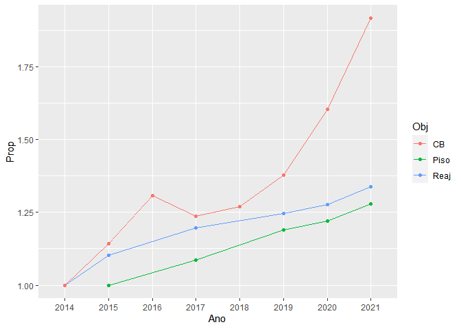

```r
ggplot(ts_df, aes(x = Ano, y = Prop, group = Obj)) +
  geom_line(aes(color = Obj)) +
  geom_point(aes(color = Obj))
```

Estes dados demonstram explicitamente uma perda gigantesca no poder de compra desta categoria, tanto com relação ao piso salarial quanto ao reajuste. Outros dados interessantes poderiam ser mobilizados por aqui, como o salário mínimo, ou até mesmo agregando categorias por setores, estados, regiões, etc.

## Referências

DIEESE. Cesta básica de alimentos. Disponível em: http://www.dieese.org.br/cesta/.

MTE. Sistema Mediador. 1997. Disponível em: http://www3.mte.gov.br/sistemas/mediador/Home.

WICKHAM, Hadley. rvest: Easily Harvest (Scrape) Web Pages. R package version 0.3.6. 2020. Disponível em: https://CRAN.R-project.org/package=rvest.

_____; et al. Welcome to the tidyverse. Journal of Open Source Software, 4(43), 1686, 2019